# Peer Assessment II

# 1 Background

As a statistical consultant working for a real estate investment firm, your task is to develop a model to predict the selling price of a given home in Ames, Iowa. Your employer hopes to use this information to help assess whether the asking price of a house is higher or lower than the true value of the house. If the home is undervalued, it may be a good investment for the firm.

# 2 Training Data and relevant packages

In order to better assess the quality of the model you will produce, the data have been randomly divided into three separate pieces: a training data set, a testing data set, and a validation data set. For now we will load the training data set, the others will be loaded and used later.

```r
load("ames_train.Rdata")
```

Use the code block below to load any necessary packages

```r
library(statsr)
library(dplyr)
library(BAS)
library(GGally)
```

```r
library(ggplot2)
library(MASS)
```

## 2.1 Part 1 - Exploratory Data Analysis (EDA)

When you first get your data, it’s very tempting to immediately begin fitting models and assessing how they perform. However, before you begin modeling, it’s absolutely essential to explore the structure of the data and the relationships between the variables in the data set.

Do a detailed EDA of the ames_train data set, to learn about the structure of the data and the relationships between the variables in the data set (refer to Introduction to Probability and Data, Week 2, for a reminder about EDA if needed). Your EDA should involve creating and reviewing many plots/graphs and considering the patterns and relationships you see.

After you have explored completely, submit the three graphs/plots that you found most informative during your EDA process, and briefly explain what you learned from each (why you found each informative).

After a detailed EDA, I have chosen the following three plots as the most informative (along with some text output). The first plot plots the relationship between 5 different numerical variables and price. It is clear that some of these variables have little influence on price (Yr.Sold), while others (area) have significant influence. This clarifies more clearly which variables may be better to include in the model.

```r
str(ames_train)
```

```
## Classes 'tbl_df', 'tbl' and 'data.frame':    1000 obs. of  81 variables:
##  $ PID            : int  909176150 905476230 911128020 535377150 534177230 908128060 902135020 528228540 923426010 908186050 ...
##  $ area           : int  856 1049 1001 1039 1665 1922 936 1246 889 1072 ...
##  $ price          : int  126000 139500 124900 114000 227000 198500 93000 187687 137500 140000 ...
##  $ MS.SubClass    : int  30 120 30 70 60 85 20 20 20 180 ...
##  $ MS.Zoning      : Factor w/ 7 levels "A (agr)","C (all)",..: 6 6 2 6 6 6 7 6 6 7 ...
##  $ Lot.Frontage   : int  NA 42 60 80 70 64 60 53 74 35 ...
##  $ Lot.Area       : int  7890 4235 6060 8146 8400 7301 6000 3710 12395 3675 ...
##  $ Street         : Factor w/ 2 levels "Grvl","Pave": 2 2 2 2 2 2 2 2 2 2 ...
##  $ Alley          : Factor w/ 2 levels "Grvl","Pave": NA NA NA NA NA NA 2 NA NA NA ...
##  $ Lot.Shape      : Factor w/ 4 levels "IR1","IR2","IR3",..: 4 4 4 4 4 4 4 4 4 4 ...
##  $ Land.Contour   : Factor w/ 4 levels "Bnk","HLS","Low",..: 4 4 4 4 4 4 1 4 4 4 ...
##  $ Utilities      : Factor w/ 3 levels "AllPub","NoSeWa",..: 1 1 1 1 1 1 1 1 1 1 ...
##  $ Lot.Config     : Factor w/ 5 levels "Corner","CulDSac",..: 1 5 5 1 5 1 5 5 1 5 ...
##  $ Land.Slope     : Factor w/ 3 levels "Gtl","Mod","Sev": 1 1 1 1 1 1 2 1 1 1 ...
```

[output cut: 67 more lines]

```r
summary(ames_train)
```

```
##       PID                 area          price         MS.SubClass
##  Min.   :5.263e+08   Min.   : 334   Min.   : 12789   Min.   : 20.00
##  1st Qu.:5.285e+08   1st Qu.:1092   1st Qu.:129763   1st Qu.: 20.00
##  Median :5.354e+08   Median :1411   Median :159467   Median : 50.00
##  Mean   :7.059e+08   Mean   :1477   Mean   :181190   Mean   : 57.15
##  3rd Qu.:9.071e+08   3rd Qu.:1743   3rd Qu.:213000   3rd Qu.: 70.00
##  Max.   :1.007e+09   Max.   :4676   Max.   :615000   Max.   :190.00
##
##    MS.Zoning    Lot.Frontage       Lot.Area       Street     Alley
##  A (agr):  0   Min.   : 21.00   Min.   :  1470   Grvl:  3   Grvl: 33
##  C (all):  9   1st Qu.: 57.00   1st Qu.:  7314   Pave:997   Pave: 34
##  FV     : 56   Median : 69.00   Median :  9317              NA's:933
##  I (all):  1   Mean   : 69.21   Mean   : 10352
##  RH     :  7   3rd Qu.: 80.00   3rd Qu.: 11650
##  RL     :772   Max.   :313.00   Max.   :215245
##  RM     :155   NA's   :167
##  Lot.Shape Land.Contour  Utilities      Lot.Config  Land.Slope
##  IR1:338   Bnk: 33      AllPub:1000   Corner :173   Gtl:962
##  IR2: 30   HLS: 38      NoSeWa:   0   CulDSac: 76   Mod: 33
##  IR3:  3   Low: 20      NoSewr:   0   FR2    : 36   Sev:  5
##  Reg:629   Lvl:909                    FR3    :  5
##                                       Inside :710
##
##
##   Neighborhood  Condition.1   Condition.2   Bldg.Type    House.Style
##  NAmes  :155   Norm   :875   Norm   :988   1Fam  :823   1Story :521
##  CollgCr: 85   Feedr  : 53   Feedr  :  6   2fmCon: 20   2Story :286
##  Somerst: 74   Artery : 23   Artery :  2   Duplex: 35   1.5Fin : 98
##  OldTown: 71   RRAn   : 14   PosN   :  2   Twnhs : 38   SLvl   : 41
##  Sawyer : 61   PosN   : 11   PosA   :  1   TwnhsE: 84   SFoyer : 36
##  Edwards: 60   RRAe   : 11   RRNn   :  1                2.5Unf : 10
##  (Other):494   (Other): 13   (Other):  0                (Other):  8
##   Overall.Qual     Overall.Cond     Year.Built   Year.Remod.Add
##  Min.   : 1.000   Min.   :1.000   Min.   :1872   Min.   :1950
##  1st Qu.: 5.000   1st Qu.:5.000   1st Qu.:1955   1st Qu.:1966
##  Median : 6.000   Median :5.000   Median :1975   Median :1992
##  Mean   : 6.095   Mean   :5.559   Mean   :1972   Mean   :1984
##  3rd Qu.: 7.000   3rd Qu.:6.000   3rd Qu.:2001   3rd Qu.:2004
##  Max.   :10.000   Max.   :9.000   Max.   :2010   Max.   :2010
##
```

[output cut: 89 more lines]

```
##  Ex  :  1   GdPrv: 43   Elev:  0     Min.   :    0.00   Min.   : 1.000
##  Fa  :  1   GdWo : 37   Gar2:  2     1st Qu.:    0.00   1st Qu.: 4.000
##  Gd  :  1   MnPrv:120   Othr:  1     Median :    0.00   Median : 6.000
##  TA  :  0   MnWw :  2   Shed: 25     Mean   :   45.81   Mean   : 6.243
##  NA's:997   NA's :798   TenC:  1     3rd Qu.:    0.00   3rd Qu.: 8.000
##                         NA's:971     Max.   :15500.00   Max.   :12.000
##
##     Yr.Sold       Sale.Type   Sale.Condition
##  Min.   :2006   WD     :863   Abnorml: 61
##  1st Qu.:2007   New    : 79   AdjLand:  2
##  Median :2008   COD    : 27   Alloca :  4
##  Mean   :2008   ConLD  :  7   Family : 17
##  3rd Qu.:2009   ConLw  :  6   Normal :834
##  Max.   :2010   Con    :  5   Partial: 82
##                 (Other): 13
```

```r
# Change certain variables to factors that should be
ames_train$MS.SubClass <- factor(ames_train$MS.SubClass)
ames_train$Overall.Cond <- factor(ames_train$Overall.Cond)
ames_train$Overall.Qual <- factor(ames_train$Overall.Qual)
# exploring missing values
missing <- sapply(ames_train, function(x) sum(is.na(x)))
missing <- sort(missing, decreasing = TRUE)
some_missing <- missing[missing > 0]
some_missing
```

```
##        Pool.QC   Misc.Feature          Alley          Fence   Fireplace.Qu
##            997            971            933            798            491
##   Lot.Frontage  Garage.Yr.Blt    Garage.Qual    Garage.Cond    Garage.Type
##            167             48             47             47             46
##  Garage.Finish      Bsmt.Qual      Bsmt.Cond  Bsmt.Exposure BsmtFin.Type.1
##             46             21             21             21             21
## BsmtFin.Type.2   Mas.Vnr.Area   BsmtFin.SF.1   BsmtFin.SF.2    Bsmt.Unf.SF
##             21              7              1              1              1
##  Total.Bsmt.SF Bsmt.Full.Bath Bsmt.Half.Bath    Garage.Cars    Garage.Area
##              1              1              1              1              1
```

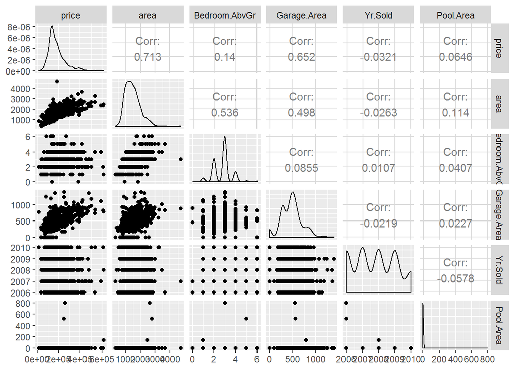

```r
# The varaiables with missing values seem to make sense for the most part...the missing data that does not have a logical explanation is limited
# Let's look at how some of the numerical variables relate to price and to each other...I will only select a few that seem like they may influce price the most obviously
numbers <- sapply(ames_train, is.integer)
numbers <- ames_train[, numbers]
numbers <- numbers %>% dplyr::select(price, area, Bedroom.AbvGr, Garage.Area, Yr.Sold, Pool.Area)
ggpairs(numbers)
```

The next plot is the relationship between area and price, the variable that is most closely correlated with price. We can see that that with a simple log transformation, price and area seem to have a linear relationship. We also can see that there are at least two outliers in the data.

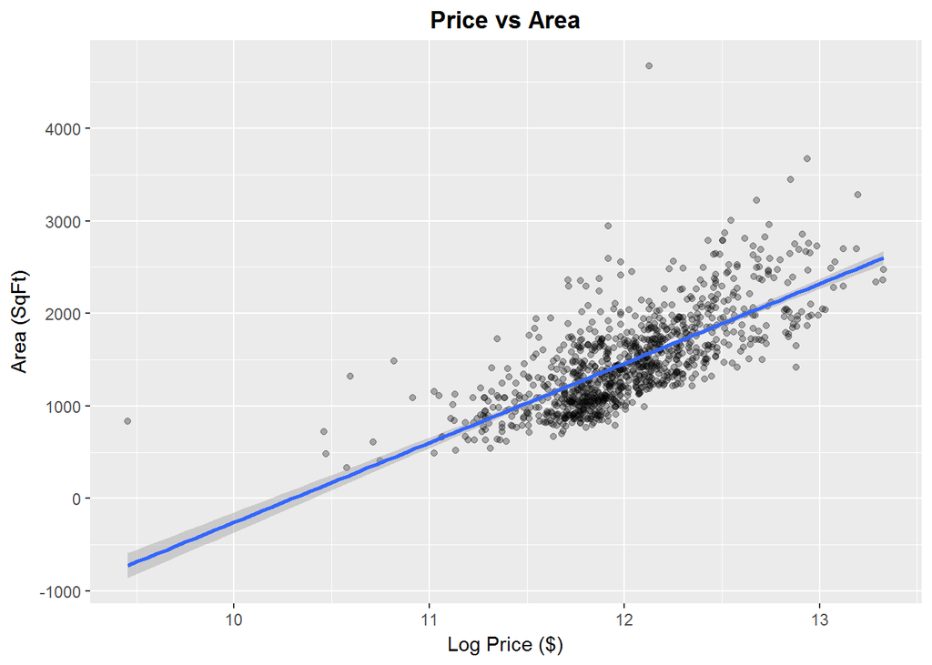

```r
ggplot(ames_train, aes(x = log(ames_train$price), y = ames_train$area)) +
  geom_point(alpha = 0.3) +
  geom_smooth(method = "lm") +
  xlab("Log Price ($)") +
  ylab("Area (SqFt)") +
  ggtitle("Price vs Area") +
  theme(plot.title = element_text(hjust = 0.5, face = "bold"))
```

```r
# clearly a couple outliers at least based on area to price relationship
outlier_1 <- ames_train %>% filter(log(ames_train$price) > 12 & ames_train$area > 4500)
outlier_1$PID
```

```
## [1] 908154205
```

```r
outlier_2 <- ames_train %>% filter(log(ames_train$price) < 9.5 & ames_train$area < 1000)
outlier_2$PID
```

```
## [1] 902207130
```

In the final plot, the relatitonship between neighborhood and price is displayed. This information is extremely helpful in determining which neighborhoods should be invested in. Certain neighborhoods offer more varaince, while in others almost all homes sell within a given range. Being able to purchase a house in the lower quantile of a neighborhood’s price range is a good indicator that this house may be priced below it’s true value.

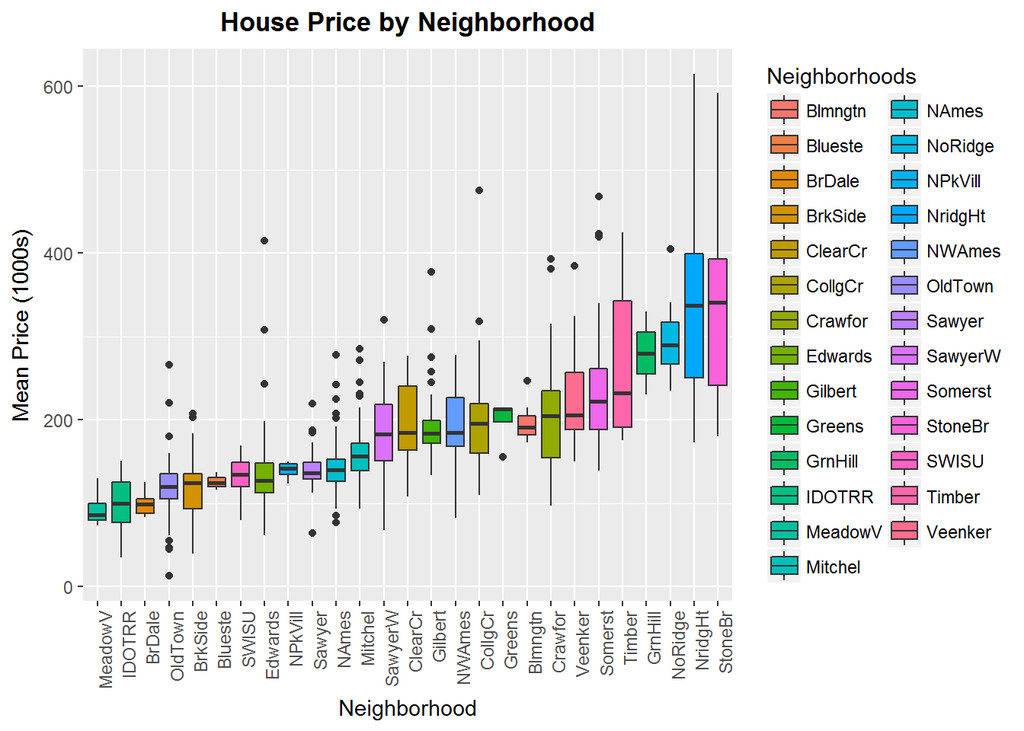

```r
# Summary statistics by neighborhood
ggplot(ames_train, aes(x = reorder(ames_train$Neighborhood, ames_train$price) , y = ames_train$price / 1000, fill = ames_train$Neighborhood)) +
  geom_boxplot() +
  xlab("Neighborhood") +
  theme(axis.text.x = element_text(angle = 90, hjust = 1)) +
  ylab("Mean Price (1000s)") +
  ggtitle("House Price by Neighborhood") +
  theme(plot.title = element_text(hjust = 0.5, face = "bold")) +
  scale_fill_discrete(name = "Neighborhoods")
```

## 2.2 Part 2 - Development and assessment of an initial model, following a semi-guided process of analysis

### 2.2.1 Section 2.1 An Initial Model

In building a model, it is often useful to start by creating a simple, intuitive initial model based on the results of the exploratory data analysis. (Note: The goal at this stage is **not** to identify the “best” possible model but rather to choose a reasonable and understandable starting point. Later you will expand and revise this model to create your final model.

Based on your EDA, select *at most* 10 predictor variables from “ames_train” and create a linear model for `price` (or a transformed version of price) using those variables. Provide the *R code* and the *summary output table* for your model, a *brief justification* for the variables you have chosen, and a *brief discussion* of the model results in context (focused on the variables that appear to be important predictors and how they relate to sales price).

Below I have made an initial model. The summary is a little “messy” as I have included multiple categorical variables, but I thought these varialbes may have some real influcence on price. I chose to transform price in order to create a smoother spread of price and hopefully increase the linearity of its relationships to other variables. I chose to include “area” and “Garage.Area” after my EDA, which showed me they both were highly correlated variables with price. “House.Style”, “Overall.Qual”, “Neighborhood”, “Exter.Qual” and “Sale.Condition” were included as I thought intuitively they would be a good indicator of price. I included “Pool.Area” and “Screen.Porch” in order to explore further if these features really influenced price.

```r
init.model <- lm(log(price) ~ log(area) + House.Style + Overall.Qual + Neighborhood + Exter.Qual + Sale.Condition + Pool.Area + Screen.Porch + Garage.Area, ames_train)
summary(init.model)
```

```
##
## Call:
## lm(formula = log(price) ~ log(area) + House.Style + Overall.Qual +
##     Neighborhood + Exter.Qual + Sale.Condition + Pool.Area +
##     Screen.Porch + Garage.Area, data = ames_train)
##
## Residuals:
##      Min       1Q   Median       3Q      Max
## -1.45093 -0.06902  0.00606  0.07943  0.69272
##
## Coefficients:
##                         Estimate Std. Error t value Pr(>|t|)
## (Intercept)            7.901e+00  2.551e-01  30.970  < 2e-16 ***
## log(area)              4.896e-01  2.803e-02  17.465  < 2e-16 ***
## House.Style1.5Unf      1.449e-02  6.089e-02   0.238 0.811935
## House.Style1Story      6.659e-02  2.225e-02   2.992 0.002840 **
## House.Style2.5Unf     -5.422e-02  5.477e-02  -0.990 0.322488
## House.Style2Story     -2.221e-02  2.223e-02  -0.999 0.317844
## House.StyleSFoyer      1.494e-01  3.649e-02   4.093 4.62e-05 ***
## House.StyleSLvl        5.366e-02  3.325e-02   1.614 0.106939
## Overall.Qual2         -1.907e-01  1.793e-01  -1.063 0.287852
## Overall.Qual3          1.733e-01  1.778e-01   0.975 0.329961
## Overall.Qual4          2.735e-01  1.730e-01   1.581 0.114156
## Overall.Qual5          3.964e-01  1.730e-01   2.291 0.022155 *
## Overall.Qual6          4.686e-01  1.736e-01   2.699 0.007080 **
## Overall.Qual7          5.339e-01  1.746e-01   3.057 0.002297 **
## Overall.Qual8          6.353e-01  1.762e-01   3.606 0.000327 ***
## Overall.Qual9          7.905e-01  1.797e-01   4.398 1.22e-05 ***
## Overall.Qual10         7.412e-01  1.888e-01   3.925 9.31e-05 ***
## NeighborhoodBlueste   -5.781e-02  1.072e-01  -0.539 0.589805
## NeighborhoodBrDale    -1.992e-01  7.496e-02  -2.657 0.008020 **
## NeighborhoodBrkSide   -7.247e-02  5.921e-02  -1.224 0.221256
## NeighborhoodClearCr    1.329e-01  6.817e-02   1.950 0.051500 .
## NeighborhoodCollgCr    5.608e-02  5.191e-02   1.080 0.280236
## NeighborhoodCrawfor    1.088e-01  5.897e-02   1.845 0.065385 .
## NeighborhoodEdwards   -7.748e-02  5.576e-02  -1.389 0.165013
## NeighborhoodGilbert    7.550e-02  5.526e-02   1.366 0.172125
## NeighborhoodGreens     5.277e-02  9.490e-02   0.556 0.578301
## NeighborhoodGrnHill    4.201e-01  1.222e-01   3.437 0.000614 ***
## NeighborhoodIDOTRR    -2.086e-01  6.061e-02  -3.442 0.000603 ***
```

[output cut: 18 more lines]

```
## Sale.ConditionAdjLand  8.374e-02  1.187e-01   0.706 0.480629
## Sale.ConditionAlloca   1.532e-01  9.507e-02   1.611 0.107476
## Sale.ConditionFamily  -8.070e-02  4.466e-02  -1.807 0.071076 .
## Sale.ConditionNormal   9.731e-02  2.175e-02   4.475 8.58e-06 ***
## Sale.ConditionPartial  1.530e-01  3.018e-02   5.071 4.77e-07 ***
## Pool.Area             -3.294e-05  1.756e-04  -0.188 0.851231
## Screen.Porch           2.997e-04  9.813e-05   3.054 0.002318 **
## Garage.Area            1.892e-04  3.311e-05   5.713 1.48e-08 ***
## ---
## Signif. codes:  0 '***' 0.001 '**' 0.01 '*' 0.05 '.' 0.1 ' ' 1
##
## Residual standard error: 0.1584 on 945 degrees of freedom
##   (1 observation deleted due to missingness)
## Multiple R-squared:  0.8658, Adjusted R-squared:  0.8582
## F-statistic:   115 on 53 and 945 DF,  p-value: < 2.2e-16
```

Upon viewing the summary of the model, it appears that some of the varialbes are likely important for creating an accurate model, but certainly some of the variables are likely best left out of the “ideal” model. “area”, “Screen.Porch”, and “Garage.Area” all seem to be variables that would be kept in the model. The categorical variables do add some value, as the R<sup>2</sup> for this model is fairly high (0.85823), but it is difficult to make a decsion given this summary as to whether they should be included going forward.

### 2.2.2 Section 2.2 Model Selection

Now either using `BAS` another stepwise selection procedure choose the “best” model you can, using your initial model as your starting point. Try at least two different model selection methods and compare their results. Do they both arrive at the same model or do they disagree? What do you think this means?

```r
bic_model <- stepAIC(init.model, trace = FALSE, k = log(nrow(ames_train)))
summary(bic_model)
```

```
##
## Call:
## lm(formula = log(price) ~ log(area) + Overall.Qual + Neighborhood +
##     Exter.Qual + Sale.Condition + Screen.Porch + Garage.Area,
##     data = ames_train)
##
## Residuals:
##      Min       1Q   Median       3Q      Max
## -1.42588 -0.07269  0.00683  0.08348  0.70830
##
## Coefficients:
##                         Estimate Std. Error t value Pr(>|t|)
## (Intercept)            8.610e+00  2.235e-01  38.527  < 2e-16 ***
## log(area)              3.899e-01  2.229e-02  17.494  < 2e-16 ***
## Overall.Qual2         -1.527e-01  1.820e-01  -0.839 0.401581
## Overall.Qual3          2.291e-01  1.802e-01   1.271 0.204002
## Overall.Qual4          3.453e-01  1.750e-01   1.974 0.048721 *
## Overall.Qual5          4.730e-01  1.748e-01   2.706 0.006939 **
## Overall.Qual6          5.409e-01  1.755e-01   3.083 0.002112 **
## Overall.Qual7          6.045e-01  1.765e-01   3.424 0.000644 ***
## Overall.Qual8          7.171e-01  1.780e-01   4.029 6.05e-05 ***
## Overall.Qual9          8.774e-01  1.815e-01   4.833 1.56e-06 ***
## Overall.Qual10         8.268e-01  1.909e-01   4.331 1.64e-05 ***
## NeighborhoodBlueste   -1.612e-01  1.073e-01  -1.502 0.133389
## NeighborhoodBrDale    -3.013e-01  7.378e-02  -4.083 4.81e-05 ***
## NeighborhoodBrkSide   -1.283e-01  5.839e-02  -2.197 0.028284 *
## NeighborhoodClearCr    1.078e-01  6.900e-02   1.563 0.118398
## NeighborhoodCollgCr    3.008e-02  5.248e-02   0.573 0.566723
## NeighborhoodCrawfor    8.511e-02  5.957e-02   1.429 0.153428
## NeighborhoodEdwards   -9.171e-02  5.641e-02  -1.626 0.104337
## NeighborhoodGilbert    2.798e-02  5.528e-02   0.506 0.612878
## NeighborhoodGreens     2.451e-02  9.634e-02   0.254 0.799242
## NeighborhoodGrnHill    4.352e-01  1.243e-01   3.502 0.000483 ***
## NeighborhoodIDOTRR    -2.628e-01  6.016e-02  -4.368 1.39e-05 ***
## NeighborhoodMeadowV   -2.415e-01  6.800e-02  -3.552 0.000402 ***
## NeighborhoodMitchel    5.186e-02  5.751e-02   0.902 0.367466
## NeighborhoodNAmes     -2.155e-02  5.405e-02  -0.399 0.690183
## NeighborhoodNoRidge    1.192e-01  5.984e-02   1.991 0.046739 *
## NeighborhoodNPkVill   -1.372e-01  9.613e-02  -1.427 0.153843
## NeighborhoodNridgHt    1.182e-01  5.601e-02   2.110 0.035103 *
```

[output cut: 11 more lines]

```
## Exter.QualTA          -1.817e-01  4.393e-02  -4.135 3.86e-05 ***
## Sale.ConditionAdjLand  1.475e-01  1.192e-01   1.238 0.215992
## Sale.ConditionAlloca   1.661e-01  9.658e-02   1.720 0.085776 .
## Sale.ConditionFamily  -7.302e-02  4.529e-02  -1.612 0.107207
## Sale.ConditionNormal   9.300e-02  2.207e-02   4.214 2.75e-05 ***
## Sale.ConditionPartial  1.578e-01  3.065e-02   5.148 3.20e-07 ***
## Screen.Porch           3.221e-04  9.875e-05   3.261 0.001148 **
## Garage.Area            2.365e-04  3.249e-05   7.280 6.97e-13 ***
## ---
## Signif. codes:  0 '***' 0.001 '**' 0.01 '*' 0.05 '.' 0.1 ' ' 1
##
## Residual standard error: 0.1611 on 952 degrees of freedom
##   (1 observation deleted due to missingness)
## Multiple R-squared:  0.8602, Adjusted R-squared:  0.8534
## F-statistic: 127.3 on 46 and 952 DF,  p-value: < 2.2e-16
```

```r
aic_model <- stepAIC(init.model, trace = FALSE, k = 2)
summary(aic_model)
```

```
##
## Call:
## lm(formula = log(price) ~ log(area) + House.Style + Overall.Qual +
##     Neighborhood + Exter.Qual + Sale.Condition + Screen.Porch +
##     Garage.Area, data = ames_train)
##
## Residuals:
##      Min       1Q   Median       3Q      Max
## -1.45092 -0.06920  0.00635  0.07968  0.69274
##
## Coefficients:
##                         Estimate Std. Error t value Pr(>|t|)
## (Intercept)            7.904e+00  2.544e-01  31.068  < 2e-16 ***
## log(area)              4.891e-01  2.788e-02  17.541  < 2e-16 ***
## House.Style1.5Unf      1.428e-02  6.085e-02   0.235 0.814561
## House.Style1Story      6.646e-02  2.223e-02   2.990 0.002865 **
## House.Style2.5Unf     -5.404e-02  5.474e-02  -0.987 0.323775
## House.Style2Story     -2.222e-02  2.221e-02  -1.000 0.317453
## House.StyleSFoyer      1.491e-01  3.644e-02   4.091 4.66e-05 ***
## House.StyleSLvl        5.305e-02  3.308e-02   1.604 0.109085
## Overall.Qual2         -1.904e-01  1.792e-01  -1.062 0.288328
## Overall.Qual3          1.737e-01  1.777e-01   0.978 0.328521
## Overall.Qual4          2.740e-01  1.728e-01   1.585 0.113206
## Overall.Qual5          3.970e-01  1.728e-01   2.297 0.021854 *
## Overall.Qual6          4.693e-01  1.735e-01   2.705 0.006943 **
## Overall.Qual7          5.344e-01  1.745e-01   3.062 0.002260 **
## Overall.Qual8          6.361e-01  1.760e-01   3.614 0.000318 ***
## Overall.Qual9          7.915e-01  1.796e-01   4.408 1.16e-05 ***
## Overall.Qual10         7.417e-01  1.887e-01   3.930 9.11e-05 ***
## NeighborhoodBlueste   -5.832e-02  1.071e-01  -0.545 0.586210
## NeighborhoodBrDale    -1.996e-01  7.488e-02  -2.666 0.007809 **
## NeighborhoodBrkSide   -7.275e-02  5.916e-02  -1.230 0.219105
## NeighborhoodClearCr    1.329e-01  6.813e-02   1.951 0.051383 .
## NeighborhoodCollgCr    5.596e-02  5.188e-02   1.079 0.281021
## NeighborhoodCrawfor    1.087e-01  5.894e-02   1.845 0.065381 .
## NeighborhoodEdwards   -7.763e-02  5.573e-02  -1.393 0.163993
## NeighborhoodGilbert    7.537e-02  5.522e-02   1.365 0.172621
## NeighborhoodGreens     5.234e-02  9.482e-02   0.552 0.581063
## NeighborhoodGrnHill    4.202e-01  1.222e-01   3.439 0.000609 ***
## NeighborhoodIDOTRR    -2.088e-01  6.057e-02  -3.448 0.000589 ***
```

[output cut: 17 more lines]

```
## Exter.QualTA          -1.618e-01  4.340e-02  -3.728 0.000204 ***
## Sale.ConditionAdjLand  8.387e-02  1.186e-01   0.707 0.479705
## Sale.ConditionAlloca   1.531e-01  9.502e-02   1.611 0.107427
## Sale.ConditionFamily  -8.052e-02  4.462e-02  -1.804 0.071484 .
## Sale.ConditionNormal   9.727e-02  2.173e-02   4.476 8.54e-06 ***
## Sale.ConditionPartial  1.530e-01  3.016e-02   5.073 4.71e-07 ***
## Screen.Porch           2.972e-04  9.717e-05   3.059 0.002285 **
## Garage.Area            1.894e-04  3.306e-05   5.731 1.34e-08 ***
## ---
## Signif. codes:  0 '***' 0.001 '**' 0.01 '*' 0.05 '.' 0.1 ' ' 1
##
## Residual standard error: 0.1584 on 946 degrees of freedom
##   (1 observation deleted due to missingness)
## Multiple R-squared:  0.8658, Adjusted R-squared:  0.8584
## F-statistic: 117.3 on 52 and 946 DF,  p-value: < 2.2e-16
```

```r
bma_model <- bas.lm(log(price) ~ log(area) + House.Style + Overall.Qual + Neighborhood + Exter.Qual + Sale.Condition + Pool.Area + Screen.Porch + Garage.Area, ames_train)
summary(bma_model)
```

```
##                       P(B != 0 | Y)  model 1     model 2     model 3
## Intercept                1.00000000   1.0000   1.0000000   1.0000000
## log(area)                1.00000000   1.0000   1.0000000   1.0000000
## House.Style1.5Unf        0.03005259   0.0000   0.0000000   0.0000000
## House.Style1Story        0.97773052   1.0000   1.0000000   1.0000000
## House.Style2.5Unf        0.04461279   0.0000   0.0000000   0.0000000
## House.Style2Story        0.32447998   0.0000   0.0000000   0.0000000
## House.StyleSFoyer        0.99951191   1.0000   1.0000000   1.0000000
## House.StyleSLvl          0.63019138   1.0000   1.0000000   1.0000000
## Overall.Qual2            0.97882708   1.0000   1.0000000   1.0000000
## Overall.Qual3            0.18125555   0.0000   0.0000000   0.0000000
## Overall.Qual4            0.40782851   0.0000   0.0000000   0.0000000
## Overall.Qual5            0.99713055   1.0000   1.0000000   1.0000000
## Overall.Qual6            0.99882689   1.0000   1.0000000   1.0000000
## Overall.Qual7            0.99953006   1.0000   1.0000000   1.0000000
## Overall.Qual8            0.99993629   1.0000   1.0000000   1.0000000
## Overall.Qual9            0.99999735   1.0000   1.0000000   1.0000000
## Overall.Qual10           0.99997356   1.0000   1.0000000   1.0000000
## NeighborhoodBlueste      0.10426734   0.0000   0.0000000   0.0000000
## NeighborhoodBrDale       0.99998152   1.0000   1.0000000   1.0000000
## NeighborhoodBrkSide      0.99982276   1.0000   1.0000000   1.0000000
## NeighborhoodClearCr      0.29905647   0.0000   0.0000000   0.0000000
## NeighborhoodCollgCr      0.03225154   0.0000   0.0000000   0.0000000
## NeighborhoodCrawfor      0.16591413   0.0000   0.0000000   0.0000000
## NeighborhoodEdwards      0.99999807   1.0000   1.0000000   1.0000000
## NeighborhoodGilbert      0.03182135   0.0000   0.0000000   0.0000000
## NeighborhoodGreens       0.02646097   0.0000   0.0000000   0.0000000
## NeighborhoodGrnHill      0.98455607   1.0000   1.0000000   1.0000000
## NeighborhoodIDOTRR       1.00000000   1.0000   1.0000000   1.0000000
## NeighborhoodMeadowV      0.99999844   1.0000   1.0000000   1.0000000
## NeighborhoodMitchel      0.02784815   0.0000   0.0000000   0.0000000
## NeighborhoodNAmes        0.99600553   1.0000   1.0000000   1.0000000
## NeighborhoodNoRidge      0.72786970   0.0000   1.0000000   0.0000000
## NeighborhoodNPkVill      0.33266777   0.0000   0.0000000   0.0000000
## NeighborhoodNridgHt      0.73252719   0.0000   1.0000000   0.0000000
## NeighborhoodNWAmes       0.15318517   0.0000   0.0000000   0.0000000
## NeighborhoodOldTown      1.00000000   1.0000   1.0000000   1.0000000
## NeighborhoodSawyer       0.46303826   0.0000   0.0000000   1.0000000
## NeighborhoodSawyerW      0.97705111   1.0000   1.0000000   1.0000000
## NeighborhoodSomerst      0.04023861   0.0000   0.0000000   0.0000000
```

[output cut: 65 more lines]

```
## Exter.QualGd            1.0000000   1.0000000
## Exter.QualTA            1.0000000   1.0000000
## Sale.ConditionAdjLand   0.0000000   0.0000000
## Sale.ConditionAlloca    0.0000000   0.0000000
## Sale.ConditionFamily    1.0000000   0.0000000
## Sale.ConditionNormal    1.0000000   1.0000000
## Sale.ConditionPartial   1.0000000   1.0000000
## Pool.Area               0.0000000   0.0000000
## Screen.Porch            1.0000000   1.0000000
## Garage.Area             1.0000000   1.0000000
## BF                      0.5117411   0.4727241
## PostProbs               0.0007000   0.0006000
## R2                      0.8591000   0.8591000
## dim                    30.0000000  30.0000000
## logmarg               883.1816442 883.1023375
```

### 2.2.3 Section 2.3 Initial Model Residuals

One way to assess the performance of a model is to examine the model’s residuals. In the space below, create a residual plot for your preferred model from above and use it to assess whether your model appears to fit the data well. Comment on any interesting structure in the residual plot (trend, outliers, etc.) and briefly discuss potential implications it may have for your model and inference / prediction you might produce.

### 2.2.4 Section 2.4 Initial Model RMSE

You can calculate it directly based on the model output. Be specific about the units of your RMSE (depending on whether you transformed your response variable). The value you report will be more meaningful if it is in the original units (dollars).

### 2.2.5 Section 2.5 Overfitting

The process of building a model generally involves starting with an initial model (as you have done above), identifying its shortcomings, and adapting the model accordingly. This process may be repeated several times until the model fits the data reasonably well. However, the model may do well on training data but perform poorly out-of-sample (meaning, on a dataset other than the original training data) because the model is overly-tuned to specifically fit the training data. This is called “overfitting.” To determine whether overfitting is occurring on a model, compare the performance of a model on both in-sample and out-of-sample data sets. To look at performance of your initial model on out-of-sample data, you will use the data set `ames_test`.

```r
load("ames_test.Rdata")
```

Use your model from above to generate predictions for the housing prices in the test data set. Are the predictions significantly more accurate (compared to the actual sales prices) for the training data than the test data? Why or why not? Briefly explain how you determined that (what steps or processes did you use)?

**Note to the learner:** If in real-life practice this out-of-sample analysis shows evidence that the training data fits your model a lot better than the test data, it is probably a good idea to go back and revise the model (usually by simplifying the model) to reduce this overfitting. For simplicity, we do not ask you to do this on the assignment, however.

## 2.3 Part 3 Development of a Final Model

Now that you have developed an initial model to use as a baseline, create a final model with *at most* 20 variables to predict housing prices in Ames, IA, selecting from the full array of variables in the dataset and using any of the tools that we introduced in this specialization.

Carefully document the process that you used to come up with your final model, so that you can answer the questions below.

### 2.3.1 Section 3.1 Final Model

Provide the summary table for your model.

### 2.3.2 Section 3.2 Transformation

Did you decide to transform any variables? Why or why not? Explain in a few sentences.

### 2.3.3 Section 3.3 Variable Interaction

Did you decide to include any variable interactions? Why or why not? Explain in a few sentences.

### 2.3.4 Section 3.4 Variable Selection

What method did you use to select the variables you included? Why did you select the method you used? Explain in a few sentences.

### 2.3.5 Section 3.5 Model Testing

How did testing the model on out-of-sample data affect whether or how you changed your model? Explain in a few sentences.

## 2.4 Part 4 Final Model Assessment

### 2.4.1 Section 4.1 Final Model Residual

For your final model, create and briefly interpret an informative plot of the residuals.

### 2.4.2 Section 4.2 Final Model RMSE

For your final model, calculate and briefly comment on the RMSE.

### 2.4.3 Section 4.3 Final Model Evaluation

What are some strengths and weaknesses of your model?

### 2.4.4 Section 4.4 Final Model Validation

Testing your final model on a separate, validation data set is a great way to determine how your model will perform in real-life practice.

You will use the “ames_validation” dataset to do some additional assessment of your final model. Discuss your findings, be sure to mention: * What is the RMSE of your final model when applied to the validation data?  
* How does this value compare to that of the training data and/or testing data? * What percentage of the 95% predictive confidence (or credible) intervals contain the true price of the house in the validation data set?  
* From this result, does your final model properly reflect uncertainty?

```r
load("ames_validation.Rdata")
```

## 2.5 Part 5 Conclusion

Provide a brief summary of your results, and a brief discussion of what you have learned about the data and your model.